# 뉴스 제목으로 기사 분류하기 _ 허채범

## 출처

데이터 : https://dacon.io/competitions/official/235747/data  
한국어 불용어1 : https://deep.chulgil.me/hangugeo-bulyongeo-riseuteu/  
한국어 불용어2 : https://www.ranks.nl/stopwords/korean

```python
import pandas as pd
import numpy as np
import re

import seaborn as sns
import matplotlib.pyplot as plt

# 그래프 글씨체
import platform
if platform.system() == 'Windows':
    plt.rc('font', family='Malgun Gothic')

from sklearn.metrics import accuracy_score, log_loss
import tensorflow as tf
from tensorflow.keras import Sequential
from tensorflow.keras.layers import Dense, Embedding, LSTM, Dropout, Bidirectional
from tensorflow.keras.preprocessing.sequence import pad_sequences
from tensorflow.keras.preprocessing.text import Tokenizer
from tensorflow.keras.callbacks import EarlyStopping, ReduceLROnPlateau
from tensorflow.keras.utils import plot_model, to_categorical
from tensorflow.keras.optimizers import Adam
from keras.utils import np_utils
from konlpy.tag import Okt, Kkma, Komoran

import warnings
warnings.filterwarnings(action='ignore')
```

# 1. 데이터 관련

```python
# 데이터 로딩
train = pd.read_csv('./data/train_data.csv', encoding='euc-kr')
test = pd.read_csv('./data/test_data.csv', encoding='euc-kr')
topic = pd.read_csv('./data/topic_dict.csv', encoding='euc-kr')
```

```python
# 훈련 데이터 확인 (결측치x)
train.info()
```

```
<class 'pandas.core.frame.DataFrame'>
RangeIndex: 45654 entries, 0 to 45653
Data columns (total 3 columns):
 #   Column     Non-Null Count  Dtype
---  ------     --------------  -----
 0   index      45654 non-null  int64
 1   title      45654 non-null  object
 2   topic_idx  45654 non-null  int64
dtypes: int64(2), object(1)
memory usage: 1.0+ MB
```

```python
# train의 기사 제목(title) 확인
train.head()
```

|  | index | title | topic_idx |
| --- | --- | --- | --- |
| 0 | 0 | 인천→핀란드 항공기 결항…휴가철 여행객 분통 | 4 |
| 1 | 1 | 실리콘밸리 넘어서겠다…구글 15조원 들여 美전역 거점화 | 4 |
| 2 | 2 | 이란 외무 긴장완화 해결책은 미국이 경제전쟁 멈추는 것 | 4 |
| 3 | 3 | NYT 클린턴 측근韓기업 특수관계 조명…공과 사 맞물려종합 | 4 |
| 4 | 4 | 시진핑 트럼프에 중미 무역협상 조속 타결 희망 | 4 |

```python
y_train = train['topic_idx']
```

1) 제목이다 보니, 명사화되어 끝나는 단어들이 많음 => 단어 단위로 토큰화  
2) '...'가 많이 들어감 => 불용어 처리  
3) 영어나 한자의 경우, 국가나 국제 단체를 의미하는 경우가 대다수 => 영어나 한자 삭제  
4) 뉴스의 제목이다 보니, 비교적 신조어나 비속어 같은 것들은 없음 => 크게 신경x  
5) 제목이라서, 전체적 내용의 핵심을 담고 있기 때문에 분류가 잘 되지 않을까 생각

```python
# test의 기사 제목(title) 확인
test.head()
```

|  | index | title |
| --- | --- | --- |
| 0 | 45654 | 유튜브 내달 2일까지 크리에이터 지원 공간 운영 |
| 1 | 45655 | 어버이날 맑다가 흐려져…남부지방 옅은 황사 |
| 2 | 45656 | 내년부터 국가RD 평가 때 논문건수는 반영 않는다 |
| 3 | 45657 | 김명자 신임 과총 회장 원로와 젊은 과학자 지혜 모을 것 |
| 4 | 45658 | 회색인간 작가 김동식 양심고백 등 새 소설집 2권 출간 |

|  | 0 | 1 | 2 | 3 | 4 | 5 | 6 |
| --- | --- | --- | --- | --- | --- | --- | --- |
| topic | IT과학 | 경제 | 사회 | 생활문화 | 세계 | 스포츠 | 정치 |
| topic_idx | 0 | 1 | 2 | 3 | 4 | 5 | 6 |

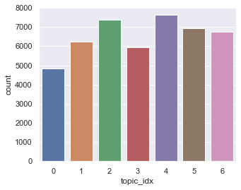

```python
# 주제별 기사 개수 확인 (for 훈련 데이터 분포)

sns.set(rc={'figure.figsize':(5,4)})
sns.set_theme(style="darkgrid")
sns.countplot(data= train, x = 'topic_idx')

topic.T
```

```python
# 기사 주제별 제목 개수
train['topic_idx'].value_counts(dropna=False, ascending=True)
```

```
0    4824
3    5933
1    6222
6    6751
5    6933
2    7362
4    7629
Name: topic_idx, dtype: int64
```

```python
print(train_lengths[0], type(train_lengths[0]))
```

[output not shown]

```python
# # 훈련 data 문장들의 길이

# titles = train['title']
# train_lengths = [len(t) for t in titles]

# plt.figure(figsize=(10, 5))
# plt.hist(train_lengths, bins=20, color='tomato')
# plt.show()
```

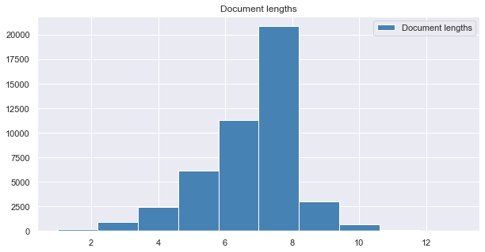

```
[가장  긴  문장] : 13 개의 단어가 있음
[가장 짧은 문장] : 1  개의 단어가 있음
```

```python
# 문장의 단어수 확인

# 띄어쓰기를 기준으로 단어를 나누었을 때, 제목 1개에 포함된 단어 수를 나타내는 컬럼 추가
train['doc_len'] = train.title.apply(lambda words: len(words.split()))

# [ doc_len ]컬럼의 평균값
mean_seq_len = np.round(train.doc_len.mean()).astype(int)

plt.figure(figsize=(10, 5))
# plt.axvline(x=mean_seq_len, color='r', linestyle='--', label=f'Sequence length mean:{mean_seq_len}')
plt.hist(train['doc_len'], bins=10, color='steelblue', label='Document lengths')
plt.title('Document lengths')
plt.legend()
plt.show()

print(f"[가장  긴  문장] : {train['doc_len'].max()} 개의 단어가 있음\n[가장 짧은 문장] : {train['doc_len'].min()}  개의 단어가 있음")
```

```python
# 제목 1개에 들어있는 단어의 개수
doc_lenDF = pd.DataFrame(train['doc_len'])
doc_lenDF.describe().T

# 평균, 최소, 최대 재확인
```

|  | count | mean | std | min | 25% | 50% | 75% | max |
| --- | --- | --- | --- | --- | --- | --- | --- | --- |
| doc_len | 45654.0 | 6.588207 | 1.474083 | 1.0 | 6.0 | 7.0 | 8.0 | 13.0 |

```python
# Train 데이터 불균형 (SMOTE 사용)
```

```python
# !pip install -U imbalanced-learn
# !pip install scikit-learn --user --upgrade
# !pip install transformers
```

# 2. 텍스트 전처리

x 1. 띄어쓰기 -> 띄어쓰기 제대로 반영

o 2. 한글 표현만 남기기 -> 날릴 수 있는 단어 가시화

o 3. Okt -> 각 뉴스 제목을 형태소 단위로 분리

o 4. 한글자 & 불용어 -> 제거

o 5. 빈도수가 많은 순으로 정렬 -> 불용어 제거

### 2-1) 띄어쓰기

```python
# 띄어쓰기 고치기 모델 => pykospacing 모델 (오류 문제로 설치 실패)
# !pip install git+https://github.com/haven-jeon/PyKoSpacing.git
```

```python
# ~종합 이렇게 붙은 것들 처리하기 위해
# (for 있는 것들 찾아서 빈도수 낮다면 제거)
print(train['title'][1149])
print(train['title'][1151])
```

```
이세신궁 찾은 아베 日 총리…G7 정상회의 성과 내겠다종합
민주 새 원내대표에 86그룹 대표 이인영…통합으로 총선승리종합2보
```

### 2-2) 한글 표현만 남기기

```python
# 한자나 영단어 => 일단 삭제, 명사들이 많아서 커버 될 것으로 생각
# 어차피 빈도수가 적어서 삭제 대상에 들어갈 것으로 판단

# 숫자 => ex) 3월  =>  숫자 날아가고 '월'  =>  1글자 불용어로 삭제 대상

def extract_word(text):
    hangul = re.compile('[^가-힣]')
    result = hangul.sub(' ', text)
    return result

print("제거 전  : ", train['title'][0])
print("제거 후  : ", extract_word(train['title'][0]))
```

```
제거 전  :  인천→핀란드 항공기 결항…휴가철 여행객 분통
제거 후  :  인천 핀란드 항공기 결항 휴가철 여행객 분통
```

```python
# 전체 데이터에 대해 extract_word를 적용
# i)

train['title'] = train['title'].apply(lambda x:extract_word(x))
test['title'] = test['title'].apply(lambda x:extract_word(x))
```

```python
# ii)

# for i in tqdm(range(len(train['title']))):
#     hangul = re.compile('[^가-힣]')
#     train['title'][i] = hangul.sub(' ', train['title'][i])

# for i in tqdm(range(len(train['title']))):
#     hangul = re.compile('[^가-힣]')
#     test['title'][i] = hangul.sub(' ', test['title'][i])
```

```python
train['title']
```

```
0                  인천 핀란드 항공기 결항 휴가철 여행객 분통
1            실리콘밸리 넘어서겠다 구글   조원 들여  전역 거점화
2            이란 외무 긴장완화 해결책은 미국이 경제전쟁 멈추는 것
3              클린턴 측근 기업 특수관계 조명 공과 사 맞물려종합
4                 시진핑 트럼프에 중미 무역협상 조속 타결 희망
                        ...
45649            금융 미국    스티펠과 제휴 선진국 시장 공략
45650        보 서울시교육청 신종코로나 확산에 개학 연기 휴업 검토
45651           게시판 키움증권      키움 영웅전 실전투자대회
45652                     답변하는 배기동 국립중앙박물관장
45653         한국인터넷기자상 시상식 내달  일 개최 특별상 김성후
Name: title, Length: 45654, dtype: object
```

### 2-3) 토큰화 ( Okt 사용 )

```python
# 구성하는 형태소를 살피기 위해 토큰화 진행
okt = Okt()
words = " ".join(train['title'].tolist())
words = okt.morphs(words,stem=True)
print(len(words))
```

```
432062
```

### 2-4) 한글자로 된 단어 삭제

```python
# 한글자로 된 단어 삭제
remove_one_word = [x for x in words if len(x)>1]
len(remove_one_word)
```

```
333824
```

```python
# 한글자로 구분된 것 삭제 후, 카운팅
from collections import Counter
Counter(remove_one_word).most_common()
```

```
[('하다', 4288),
 ('종합', 4056),
 ('대통령', 1723),
 ('한국', 1456),
 ('으로', 1413),
 ('억원', 908),
 ('삼성', 904),
 ('이란', 856),
 ('되다', 852),
 ('감독', 778),
 ('출시', 778),
 ('경기', 760),
 ('만에', 754),
 ('없다', 742),
 ('게시판', 735),
 ('에서', 714),
 ('트럼프', 702),
 ('보다', 698),
 ('신간', 686),
 ('까지', 682),
 ('정부', 603),
 ('투자', 599),
 ('개발', 594),
 ('분기', 584),
 ('대다', 582),
 ('부터', 579),
 ('서울', 573),
 ('지원', 557),
 ('최고', 517),
 ('중국', 511),
 ('올해', 508),
 ('민주', 496),
 ('개최', 487),
 ('영업', 479),
 ('세계', 472),
 ('현대', 470),
 ('미국', 462),
 ('공개', 459),
 ('기업', 451),
 ('기술', 451),
```

[output cut: 946 more lines]

```
 ('발간', 68),
 ('공습', 67),
 ('유력', 67),
 ('도착', 67),
 ('창업', 67),
 ('공세', 67),
 ('투입', 67),
 ('주주', 67),
 ('무대', 67),
 ('테크', 67),
 ('손실', 67),
 ('네타냐후', 66),
 ('유치', 66),
 ('이르다', 66),
 ...]
```

- 빈도수 위주로 출력하였는데, 아직까지 불용어가 많이 보임
- 불용어 사전 추가 => '하다','으로','되다' 등 이런 것들은 불용어리스트로 정의해 한번 더 걸러내야 함

### 2-5) 빈도수로 정렬 후, 불용어 제거

```python
# 1차 불용어를 제거 (기존의 다운받은 불용어 txt 우선 실행)
with open('data/stopwords.txt', 'r') as f:
    list_file = f.readlines()
stopwords = list_file[0].split(",")

remove_stopwords = [x for x in remove_one_word if x not in stopwords]
len(remove_stopwords)
```

```
306687
```

```python
# 한글자로 구분된 것 삭제 후, 카운팅
from collections import Counter
# words.sort()
Counter(remove_stopwords).most_common()
```

```
[('종합', 4056),
 ('대통령', 1723),
 ('한국', 1456),
 ('억원', 908),
 ('삼성', 904),
 ('감독', 778),
 ('출시', 778),
 ('경기', 760),
 ('게시판', 735),
 ('트럼프', 702),
 ('신간', 686),
 ('정부', 603),
 ('투자', 599),
 ('개발', 594),
 ('분기', 584),
 ('서울', 573),
 ('지원', 557),
 ('최고', 517),
 ('중국', 511),
 ('민주', 496),
 ('개최', 487),
 ('영업', 479),
 ('세계', 472),
 ('현대', 470),
 ('미국', 462),
 ('공개', 459),
 ('기업', 451),
 ('기술', 451),
 ('증권', 441),
 ('코로나', 440),
 ('작년', 434),
 ('대표', 432),
 ('금융', 430),
 ('시장', 428),
 ('게임', 417),
 ('최대', 417),
 ('김정은', 412),
 ('총리', 408),
 ('북한', 400),
 ('월드컵', 396),
```

[output cut: 946 more lines]

```
 ('웨어', 63),
 ('여파', 63),
 ('폐쇄', 63),
 ('반등', 63),
 ('별세', 63),
 ('채널', 63),
 ('세기', 63),
 ('동부', 63),
 ('매각', 63),
 ('해임', 63),
 ('조명', 62),
 ('워싱턴', 62),
 ('적극', 62),
 ('축소', 62),
 ...]
```

```python
# 2차 불용어를 제거 ( txt 파일명을 따로 하여 추가적으로 불용어 제거 실행 )
with open('data/stopwords_2.txt', 'r') as f:
    list_file = f.readlines()
stopwords = list_file[0].split(",")
remove_stopwords = [x for x in remove_stopwords if x not in stopwords]
len(remove_stopwords)
```

```
292107
```

```python
# 추가된 단어
print(stopwords)
```

```
['하다', '으로', '되다', '만에', '없다', '에서', '보다', '까지', '대다', '부터', '있다', '돼다', '받다', '않다', '에도', '맞다', '이다', '추다', '가다', '번째', '만들다', '서다', '다시', '관련', '늘다', '위해', '많다', '주다', '나오다', '아니다', '함께', '만나다', '들다', '하고', '오르다', '알다', '열리다', '놓다', '이후', '이번', '없이', '지만', '어떻다', '같다', '따르다', '자다', '잇다', '키우다', '찾…
```

```python
# 재확인 ( for 개인적으로 불용어 사전에 추가할 단어 탐색 )
from collections import Counter
Counter(remove_stopwords).most_common()

# 하다, 으로 등 상위에 랭크 되어 있던 것들이 사라짐 => 제대로 제거됨
```

```
[('대통령', 1723),
 ('한국', 1456),
 ('삼성', 904),
 ('감독', 778),
 ('출시', 778),
 ('경기', 760),
 ('게시판', 735),
 ('트럼프', 702),
 ('신간', 686),
 ('정부', 603),
 ('투자', 599),
 ('개발', 594),
 ('분기', 584),
 ('서울', 573),
 ('지원', 557),
 ('최고', 517),
 ('중국', 511),
 ('민주', 496),
 ('개최', 487),
 ('영업', 479),
 ('세계', 472),
 ('현대', 470),
 ('미국', 462),
 ('공개', 459),
 ('기업', 451),
 ('기술', 451),
 ('증권', 441),
 ('코로나', 440),
 ('작년', 434),
 ('대표', 432),
 ('금융', 430),
 ('시장', 428),
 ('게임', 417),
 ('최대', 417),
 ('김정은', 412),
 ('총리', 408),
 ('북한', 400),
 ('월드컵', 396),
 ('서비스', 396),
 ('사망', 393),
```

[output cut: 946 more lines]

```
 ('임금', 58),
 ('정국', 58),
 ('메시', 58),
 ('독립', 58),
 ('먼저', 58),
 ('스포츠', 58),
 ('심판', 58),
 ('무실점', 58),
 ('그리스', 58),
 ('은퇴', 58),
 ('압수수색', 58),
 ('붕괴', 58),
 ('판단', 58),
 ('이어지다', 58),
 ...]
```